# Starbucks Capstone Challenge

### Introduction

This data set contains simulated data that mimics customer behavior on the Starbucks rewards mobile app. Once every few days, Starbucks sends out an offer to users of the mobile app. An offer can be merely an advertisement for a drink or an actual offer such as a discount or BOGO (buy one get one free). Some users might not receive any offer during certain weeks.

In this section we will use the cleaned datasets to make predictions about the user behavior:  
How many offers will our users view?

# Data Sets

The data is contained in three files:

- portfolio.json - containing offer ids and meta data about each offer (duration, type, etc.)
- profile.json - demographic data for each customer
- transcript.json - records for transactions, offers received, offers viewed, and offers completed

Here is the schema and explanation of each variable in the files:

**portfolio.json**

- id (string) - offer id
- offer_type (string) - type of offer ie BOGO, discount, informational
- difficulty (int) - minimum required spend to complete an offer
- reward (int) - reward given for completing an offer
- duration (int) - time for offer to be open, in days
- channels (list of strings)

**profile.json**

- age (int) - age of the customer
- became_member_on (int) - date when customer created an app account
- gender (str) - gender of the customer (note some entries contain 'O' for other rather than M or F)
- id (str) - customer id
- income (float) - customer's income

**transcript.json**

- event (str) - record description (ie transaction, offer received, offer viewed, etc.)
- person (str) - customer id
- time (int) - time in hours since start of test. The data begins at time t=0
- value - (dict of strings) - either an offer id or transaction amount depending on the record

# Import Packages

```python
#import holy grail of data science
import pandas as pd
import numpy as np

#helper imports
from cleaner_help import transcript_cleaner

#more imports
import math
import json
import matplotlib.pyplot as plt
import pickle
import seaborn as sns
from scipy import stats
from sklearn.preprocessing import MinMaxScaler
from sklearn.cluster import KMeans, MiniBatchKMeans
from sklearn.metrics import silhouette_score, confusion_matrix, f1_score, classification_report
from sklearn.model_selection import train_test_split, GridSearchCV
from sklearn.naive_bayes import GaussianNB
from sklearn.utils.multiclass import unique_labels
from sklearn.neighbors import KNeighborsClassifier
from sklearn.linear_model import LogisticRegression
from sklearn.svm import SVC
from sklearn.pipeline import Pipeline
from sklearn.ensemble import RandomForestClassifier
from sklearn.neural_network import MLPClassifier
from plot_help import model_evaluation



#matplot magic
%matplotlib inline
```

# Load Data

```python
#conver median imputed values back to dataframe
user_df =pd.read_csv("data/user_df_median.csv")
user_df = user_df.drop(columns=['Unnamed: 0'])
```

# Predict User Interactions

## Offer Seen

```python
#recall how dataframe looks like
user_df.head()
```

|  | person | offer received | offer viewed | offer completed | transaction | reward_infl | amount_infl | email | mobile | social | ... | avg_difficulty | time_to_open | time_to_complete | total_amount | amount_pct | age | gender | income | seen_ratio | completed_ratio |
| --- | --- | --- | --- | --- | --- | --- | --- | --- | --- | --- | --- | --- | --- | --- | --- | --- | --- | --- | --- | --- | --- |
| 0 | 0.0 | 5.0 | 5.0 | 2.0 | 6.0 | 5.0 | 10.52 | 5.0 | 4.0 | 3.0 | ... | 12.0 | 0.083929 | 0.285714 | 20.40 | 0.515686 | 55.0 | 2.0 | 64000.0 | 1.0 | 0.40 |
| 1 | 1.0 | 2.0 | 0.0 | 1.0 | 0.0 | 5.0 | 0.00 | 2.0 | 2.0 | 0.0 | ... | 2.0 | 1.000000 | 1.000000 | 77.01 | 0.000000 | 55.0 | 0.0 | 112000.0 | 0.0 | 0.50 |
| 2 | 2.0 | 2.0 | 2.0 | 0.0 | 0.0 | 0.0 | 0.00 | 2.0 | 2.0 | 1.0 | ... | 2.0 | 0.000000 | 1.000000 | 14.30 | 0.000000 | 55.0 | 2.0 | 64000.0 | 1.0 | 0.00 |
| 3 | 3.0 | 4.0 | 4.0 | 3.0 | 3.0 | 20.0 | 69.28 | 4.0 | 4.0 | 3.0 | ... | 5.0 | 0.234127 | 0.785714 | 159.27 | 0.434985 | 75.0 | 0.0 | 100000.0 | 1.0 | 0.75 |
| 4 | 4.0 | 5.0 | 3.0 | 0.0 | 1.0 | 0.0 | 1.09 | 5.0 | 2.0 | 1.0 | ... | 7.0 | 0.012500 | 1.000000 | 4.65 | 0.234409 | 55.0 | 2.0 | 64000.0 | 0.6 | 0.00 |

5 rows × 24 columns

```python
#make columns integers
user_df[['offer received', 'offer completed', 'reward_infl', 'time_to_open', 'offer viewed']]= \
        user_df[['offer received', 'offer completed', 'reward_infl', 'time_to_open', 'offer viewed']].astype(int)
```

```python
#see columns
user_df.columns
```

```
Index(['person', 'offer received', 'offer viewed', 'offer completed',
       'transaction', 'reward_infl', 'amount_infl', 'email', 'mobile',
       'social', 'web', 'bogo', 'discount', 'informational', 'avg_difficulty',
       'time_to_open', 'time_to_complete', 'total_amount', 'amount_pct', 'age',
       'gender', 'income', 'seen_ratio', 'completed_ratio'],
      dtype='object')
```

```python
#drop features that can lead to oferfitting

X_seen = user_df.drop(columns=['offer viewed',
                               'seen_ratio'])
```

```python
#divide data among training and testing
X_seen_train, X_seen_test, y_seen_train, y_seen_test = \
train_test_split(X_seen,
                 np.array(user_df['offer viewed']),
                 test_size=0.20, random_state=42)
```

```python
#instantiate scaler
X_seen_scaler = MinMaxScaler()

#fit to X_train
X_seen_scaler.fit(X_seen_train)

#transform train data
X_seen_train_scaled = X_seen_scaler.transform(X_seen_train)

#transform test data using scaler from training
X_seen_test_scaled = X_seen_scaler.transform(X_seen_test)
```

use [template](https://scikit-learn.org/stable/auto_examples/model_selection/plot_confusion_matrix.html) from sklearn to create function that plots confusion matrix

## Naive Bayes

```python
#instantiate NB
clf_nb = GaussianNB()

#fit
clf_nb.fit(X_seen_train, y_seen_train)
```

```
GaussianNB(priors=None, var_smoothing=1e-09)
```

```python
y_nb_pred = clf_nb.predict(X_seen_test)
```

```
Accuracy = 0.347

classification report:

              precision    recall  f1-score   support

           0       0.10      0.97      0.18        29
           1       0.15      0.19      0.16       183
           2       0.35      0.22      0.27       593
           3       0.45      0.35      0.39      1001
           4       0.39      0.40      0.40       904
           5       0.38      0.28      0.33       538
           6       0.31      0.84      0.45       137

   micro avg       0.35      0.35      0.35      3385
   macro avg       0.30      0.46      0.31      3385
weighted avg       0.38      0.35      0.35      3385



Confusion matrix, without normalization
Confusion Matrix:
[[ 28   0   1   0   0   0   0]
 [ 97  34  28  11   9   2   2]
 [ 89 122 129 149  74  16  14]
 [ 48  59 175 354 254  62  49]
 [ 16  10  37 254 364 142  81]
 [  7   5   3  24 236 152 111]
 [  0   0   0   0   1  21 115]]
Plotted confusion matrix
```

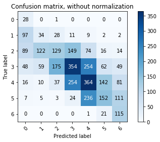

```python
model_evaluation(y_seen_test,y_nb_pred,
                      saveloc='plots/nb_seen_confusion.png')
```

## K Nearest Neighors

```python
#instantiate a knn classifier
clf_knn = KNeighborsClassifier()

#fit training data
clf_knn.fit(X_seen_train_scaled, y_seen_train)

#get predictions
y_knn_pred = clf_knn.predict(X_seen_test_scaled)
```

```
Accuracy = 0.419

classification report:

              precision    recall  f1-score   support

           0       0.27      0.14      0.18        29
           1       0.39      0.29      0.33       183
           2       0.40      0.46      0.43       593
           3       0.43      0.46      0.44      1001
           4       0.42      0.43      0.42       904
           5       0.44      0.38      0.41       538
           6       0.39      0.31      0.35       137

   micro avg       0.42      0.42      0.42      3385
   macro avg       0.39      0.35      0.37      3385
weighted avg       0.42      0.42      0.42      3385



Confusion matrix, without normalization
Confusion Matrix:
[[  4  16   7   1   1   0   0]
 [  7  53  78  34   8   2   1]
 [  3  32 271 194  77  14   2]
 [  0  27 209 456 232  67  10]
 [  0   4  77 276 389 133  25]
 [  1   2  26  90 187 204  28]
 [  0   1   6   8  38  41  43]]
Plotted confusion matrix
```

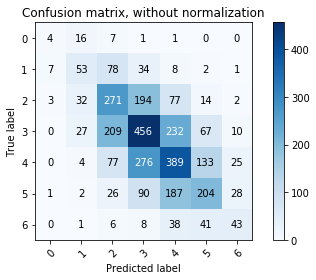

```python
model_evaluation(y_seen_test,
                      y_knn_pred,
                      saveloc='plots/knn_seen_confusion.png')
```

## Logistic Regression

```python
clf_lr = LogisticRegression(solver = 'lbfgs').fit(X_seen_train_scaled, y_seen_train)
```

```python
y_lr_pred = clf_lr.predict(X_seen_test_scaled)
```

```
Accuracy = 0.431

classification report:

              precision    recall  f1-score   support

           0       0.00      0.00      0.00        29
           1       0.56      0.35      0.43       183
           2       0.45      0.40      0.43       593
           3       0.47      0.57      0.51      1001
           4       0.40      0.51      0.45       904
           5       0.32      0.22      0.26       538
           6       0.64      0.05      0.09       137

   micro avg       0.43      0.43      0.43      3385
   macro avg       0.41      0.30      0.31      3385
weighted avg       0.43      0.43      0.42      3385



Confusion matrix, without normalization
Confusion Matrix:
[[  0  29   0   0   0   0   0]
 [  0  64  96  18   5   0   0]
 [  0  16 237 269  60  10   1]
 [  0   5 123 571 256  45   1]
 [  0   1  44 308 461  90   0]
 [  0   0  20  52 344 120   2]
 [  0   0   1   0  21 108   7]]
Plotted confusion matrix
```

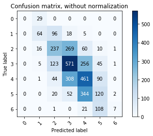

```python
model_evaluation(y_seen_test,
                      y_lr_pred,
                      saveloc='plots/lr_seen_confusion.png')
```

## SVM

```python
#instantiate SVC
clf_svc = SVC()
#fit
clf_svc.fit(X_seen_train_scaled, y_seen_train)
#make predict
y_svc_pred = clf_svc.predict(X_seen_test_scaled)
```

```
Accuracy = 0.460

classification report:

              precision    recall  f1-score   support

           0       0.00      0.00      0.00        29
           1       0.57      0.33      0.42       183
           2       0.48      0.46      0.47       593
           3       0.48      0.47      0.48      1001
           4       0.43      0.53      0.47       904
           5       0.44      0.39      0.41       538
           6       0.49      0.46      0.48       137

   micro avg       0.46      0.46      0.46      3385
   macro avg       0.41      0.38      0.39      3385
weighted avg       0.46      0.46      0.46      3385



Confusion matrix, without normalization
Confusion Matrix:
[[  0  27   2   0   0   0   0]
 [  0  60  98  21   3   1   0]
 [  0  16 275 225  63  13   1]
 [  0   2 149 474 307  59  10]
 [  0   0  37 233 478 130  26]
 [  0   0  16  36 250 208  28]
 [  0   0   1   0  16  57  63]]
```

```
Plotted confusion matrix
```

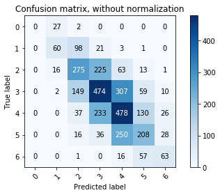

```python
model_evaluation(y_seen_test,
                      y_svc_pred,
                      saveloc='plots/svc_seen_confusion.png')
```

```python
#instantiate a pipeline for SVC
pipeline_svc = Pipeline([
    ('scaler', MinMaxScaler()),
    ('SVC', SVC())

])
```

```python
pipeline_svc.get_params().keys()
```

```
dict_keys(['memory', 'steps', 'scaler', 'SVC', 'scaler__copy', 'scaler__feature_range', 'SVC__C', 'SVC__cache_size', 'SVC__class_weight', 'SVC__coef0', 'SVC__decision_function_shape', 'SVC__degree', 'SVC__gamma', 'SVC__kernel', 'SVC__max_iter', 'SVC__probability', 'SVC__random_state', 'SVC__shrinkin…
```

```python
svc_pipe_grid= {'SVC__C': [1, 10, 100, 1000],
                'SVC__kernel': ['rbf', 'poly'],
                'SVC__gamma': [1e-2, 1e-3, 1e-4]}
```

```python
svc_grid_pipe = GridSearchCV(pipeline_svc, svc_pipe_grid, n_jobs=-1, cv=5)
```

```python
svc_grid_pipe.fit(X_seen_train, y_seen_train)
```

```
GridSearchCV(cv=5, error_score='raise-deprecating',
       estimator=Pipeline(memory=None,
     steps=[('scaler', MinMaxScaler(copy=True, feature_range=(0, 1))), ('SVC', SVC(C=1.0, cache_size=200, class_weight=None, coef0=0.0,
  decision_function_shape='ovr', degree=3, gamma='auto_deprecated',
  kernel='rbf', max_iter=-1, probability=False, random_state=None,
  shrinking=True, tol=0.001, verbose=False))]),
       fit_params=None, iid='warn', n_jobs=-1,
       param_grid={'SVC__C': [1, 10, 100, 1000], 'SVC__kernel': ['rbf', 'poly'], 'SVC__gamma': [0.01, 0.001, 0.0001]},
       pre_dispatch='2*n_jobs', refit=True, return_train_score='warn',
       scoring=None, verbose=0)
```

```python
y_svc_grid_pipe_pred = svc_grid_pipe.predict(X_seen_test)
```

```
Accuracy = 0.512

classification report:

              precision    recall  f1-score   support

           0       0.61      0.48      0.54        29
           1       0.59      0.33      0.42       183
           2       0.49      0.55      0.52       593
           3       0.53      0.47      0.50      1001
           4       0.50      0.52      0.51       904
           5       0.52      0.57      0.54       538
           6       0.46      0.63      0.53       137

   micro avg       0.51      0.51      0.51      3385
   macro avg       0.53      0.51      0.51      3385
weighted avg       0.52      0.51      0.51      3385



Confusion matrix, without normalization
Confusion Matrix:
[[ 14  15   0   0   0   0   0]
 [  7  60  99  14   3   0   0]
 [  2  15 325 179  52  17   3]
 [  0   9 165 469 278  66  14]
 [  0   2  44 179 473 174  32]
 [  0   0  23  41 116 305  53]
 [  0   0   2   3  26  20  86]]
Plotted confusion matrix
```

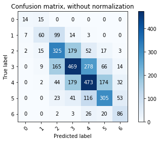

```python
model_evaluation(y_seen_test,
                 y_svc_grid_pipe_pred,
                 saveloc='plots/svc_pipe_seen_confusion.png')
```

## Random Forest

```python
#instantiate a pipeline for SVC
pipeline_forest = Pipeline([
    ('scaler', MinMaxScaler()),
    ('clf', RandomForestClassifier(n_jobs=-1))
])
```

```python
pipeline_forest.get_params().keys()
```

```
dict_keys(['memory', 'steps', 'scaler', 'clf', 'scaler__copy', 'scaler__feature_range', 'clf__bootstrap', 'clf__class_weight', 'clf__criterion', 'clf__max_depth', 'clf__max_features', 'clf__max_leaf_nodes', 'clf__min_impurity_decrease', 'clf__min_impurity_split', 'clf__min_samples_leaf', 'clf__min_s…
```

```python
#params for pipeline
forest_pipe_grid = {
    'clf__n_estimators': [10, 50, 100, 150],
    'clf__max_depth': [2, 3, 4, 5],
    'clf__min_samples_split': [2, 4, 6],
    'clf__warm_start': [False, True],
    'clf__min_samples_leaf': [1, 2, 3, 4]
                   }
```

```python
#instantiate
forest_grid_pipe = GridSearchCV(pipeline_forest, forest_pipe_grid, cv=5,n_jobs=-1)
```

```python
forest_grid_pipe.fit(X_seen_train, y_seen_train)
```

```
GridSearchCV(cv=5, error_score='raise-deprecating',
       estimator=Pipeline(memory=None,
     steps=[('scaler', MinMaxScaler(copy=True, feature_range=(0, 1))), ('clf', RandomForestClassifier(bootstrap=True, class_weight=None, criterion='gini',
            max_depth=None, max_features='auto', max_leaf_nodes=None,
            min_impurity_decrease=0.0, min_impurity_split=None,
            min_..._jobs=-1,
            oob_score=False, random_state=None, verbose=0,
            warm_start=False))]),
       fit_params=None, iid='warn', n_jobs=-1,
       param_grid={'clf__n_estimators': [10, 50, 100, 150], 'clf__max_depth': [2, 3, 4, 5], 'clf__min_samples_split': [2, 4, 6], 'clf__warm_start': [False, True], 'clf__min_samples_leaf': [1, 2, 3, 4]},
       pre_dispatch='2*n_jobs', refit=True, return_train_score='warn',
       scoring=None, verbose=0)
```

```python
y_forest_grid_pipe_pred = forest_grid_pipe.predict(X_seen_test)
```

```
Accuracy = 0.514

classification report:

              precision    recall  f1-score   support

           0       0.00      0.00      0.00        29
           1       0.60      0.36      0.45       183
           2       0.52      0.42      0.47       593
           3       0.52      0.54      0.53      1001
           4       0.49      0.58      0.53       904
           5       0.52      0.60      0.55       538
           6       0.56      0.31      0.40       137

   micro avg       0.51      0.51      0.51      3385
   macro avg       0.46      0.40      0.42      3385
weighted avg       0.51      0.51      0.51      3385



Confusion matrix, without normalization
Confusion Matrix:
[[  0  29   0   0   0   0   0]
 [  0  65  78  36   3   1   0]
 [  0  13 252 252  66  10   0]
 [  0   2 113 537 279  65   5]
 [  0   0  34 162 522 171  15]
 [  0   0   6  49 147 322  14]
 [  0   0   1   1  38  54  43]]
```

```
Plotted confusion matrix
```

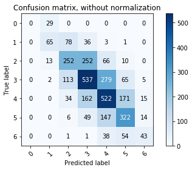

```python
model_evaluation(y_seen_test,
                 y_forest_grid_pipe_pred,
                 saveloc='plots/forest_pipe_seen_confusion.png')
```

## Multilayer Perceptron

```python
mlp = MLPClassifier(verbose=True)
```

```python
# memory usage can be come intensive with too many params

mlp_grid = {
    'hidden_layer_sizes': [(50,50,50), (50,100,50)],
    #'activation': ['tanh', 'relu'],
    #'solver': ['sgd', 'adam'],
    'alpha': [0.0001, 0.001, 0.01],
    'learning_rate_init': [0.008,0.001],
    #'learning_rate': ['constant','adaptive'],
}
```

```python
clf_mlp = GridSearchCV(mlp, mlp_grid, cv=5,n_jobs=-1)
```

```python
clf_mlp.fit(X_seen_train_scaled, y_seen_train)
```

[output not shown]

[output cut: 145 more lines]

[output not shown]

```
GridSearchCV(cv=5, error_score='raise-deprecating',
       estimator=MLPClassifier(activation='relu', alpha=0.0001, batch_size='auto', beta_1=0.9,
       beta_2=0.999, early_stopping=False, epsilon=1e-08,
       hidden_layer_sizes=(100,), learning_rate='constant',
       learning_rate_init=0.001, max_iter=200, momentum=0.9,
       n_iter_no_change=10, nesterovs_momentum=True, power_t=0.5,
       random_state=None, shuffle=True, solver='adam', tol=0.0001,
       validation_fraction=0.1, verbose=True, warm_start=False),
       fit_params=None, iid='warn', n_jobs=-1,
       param_grid={'hidden_layer_sizes': [(50, 50, 50), (50, 100, 50)], 'alpha': [0.0001, 0.001, 0.01], 'learning_rate_init': [0.008, 0.001]},
       pre_dispatch='2*n_jobs', refit=True, return_train_score='warn',
       scoring=None, verbose=0)
```

```python
y_mlp_pred = clf_mlp.predict(X_seen_test_scaled)
```

```python
np.mean(y_mlp_pred == y_seen_test)
```

```
0.5341211225997046
```

```
Accuracy = 0.534

classification report:

              precision    recall  f1-score   support

           0       0.63      0.41      0.50        29
           1       0.48      0.57      0.52       183
           2       0.51      0.59      0.55       593
           3       0.57      0.46      0.51      1001
           4       0.53      0.55      0.54       904
           5       0.55      0.57      0.56       538
           6       0.50      0.59      0.54       137

   micro avg       0.53      0.53      0.53      3385
   macro avg       0.54      0.53      0.53      3385
weighted avg       0.54      0.53      0.53      3385



Confusion matrix, without normalization
Confusion Matrix:
[[ 12  16   1   0   0   0   0]
 [  6 104  57  10   3   1   2]
 [  1  58 351 112  45  20   6]
 [  0  30 197 456 247  57  14]
 [  0   5  61 174 499 145  20]
 [  0   3  19  40 132 305  39]
 [  0   0   0   6  19  31  81]]
Plotted confusion matrix
```

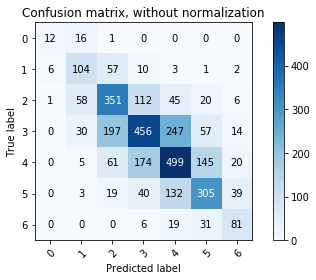

```python
model_evaluation(y_seen_test,
                 y_mlp_pred,
                 saveloc='plots/mlp_seen_confusion.png')
```